# ggplot2 examples (Bio-data Club)

Ram Thapa

2020-08-21

This examples file is also available [here](https://github.com/raamthapa/ggplot2-biodataclub).

Data visualization is important in most phases of data analysis workflow and being able to create visualizations of data is a key step in being able to effectively communicate information and findings to others.

{ggplot2} is a plotting framework that is (relatively) easy to use, powerful and hassle-free. It is based on a set of principles “Grammar of graphic” and is designed to work in a layered fashion, starting with a layer showing the data then adding layers of graphical objects, annotations and statistical summaries.

**Packages and data**

```r
library(tidyverse)
library(palmerpenguins)
library(ggridges)
library(patchwork)

head(penguins)
```

| species | island | bill_length_mm | bill_depth_mm | flipper_length_mm | body_mass_g | sex | year |
| --- | --- | --- | --- | --- | --- | --- | --- |
| Adelie | Torgersen | 39.1 | 18.7 | 181 | 3750 | male | 2007 |
| Adelie | Torgersen | 39.5 | 17.4 | 186 | 3800 | female | 2007 |
| Adelie | Torgersen | 40.3 | 18.0 | 195 | 3250 | female | 2007 |
| Adelie | Torgersen | NA | NA | NA | NA | NA | 2007 |
| Adelie | Torgersen | 36.7 | 19.3 | 193 | 3450 | female | 2007 |
| Adelie | Torgersen | 39.3 | 20.6 | 190 | 3650 | male | 2007 |

## Visualizing associations among two or more variables

### Scatterplot

Relationship between bill length and flipper length

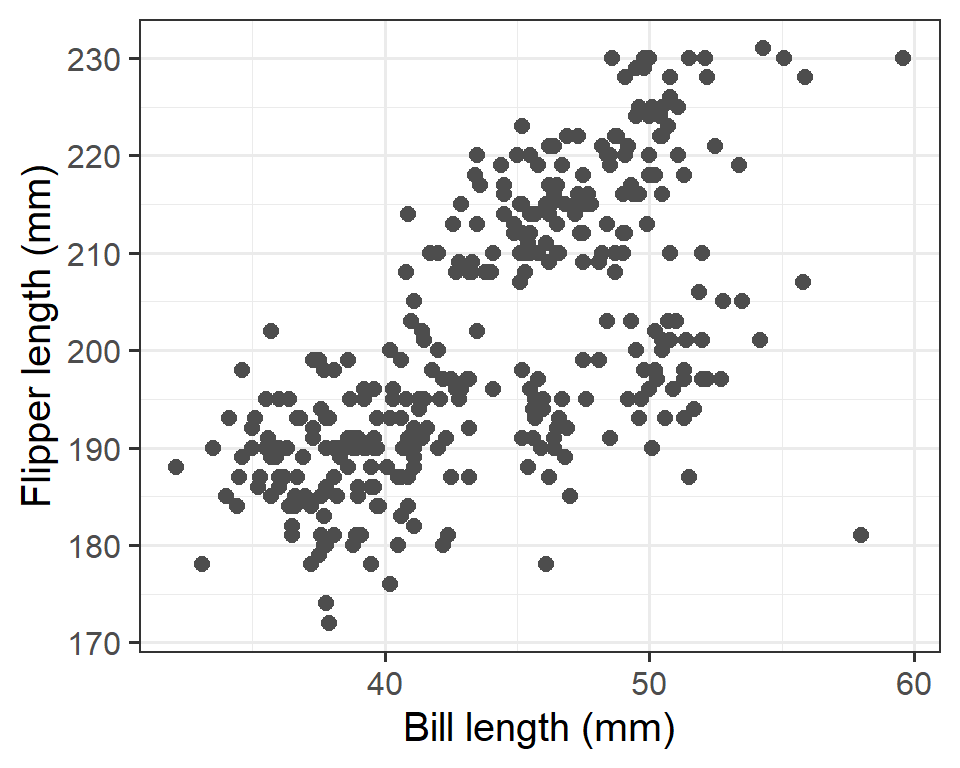

```r
# set theme to theme_bw()
theme_set(theme_bw(base_size = 15))

ggplot(data = penguins, aes(x = bill_length_mm, y = flipper_length_mm)) +
  labs(x = "Bill length (mm)", y = "Flipper length (mm)") +
  geom_point(color = "gray30", size = 2.5)
```

Mapping `color` to `sex` variable from the data

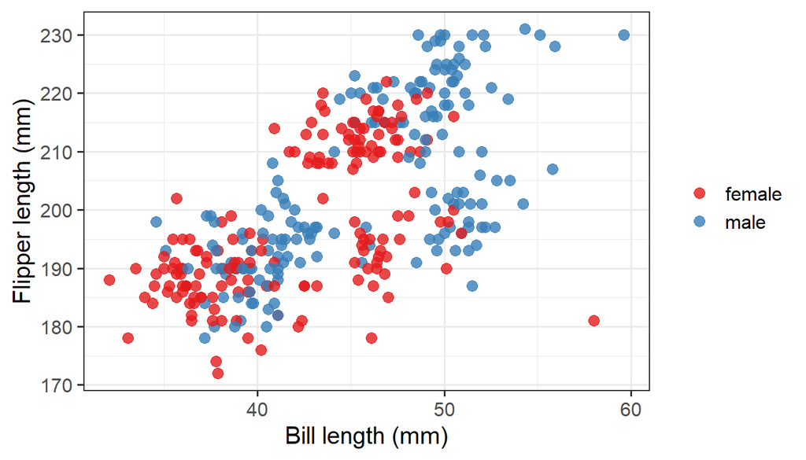

```r
scatter_sex <- ggplot(data = penguins, aes(x = bill_length_mm, y = flipper_length_mm, color = sex)) +
  geom_point(size = 3, alpha = 0.8) +
  labs(x = "Bill length (mm)", y = "Flipper length (mm)") +
  scale_color_brewer(NULL, palette = "Set1", na.translate = FALSE)

scatter_sex
```

Avoid overplotting using jitter plot

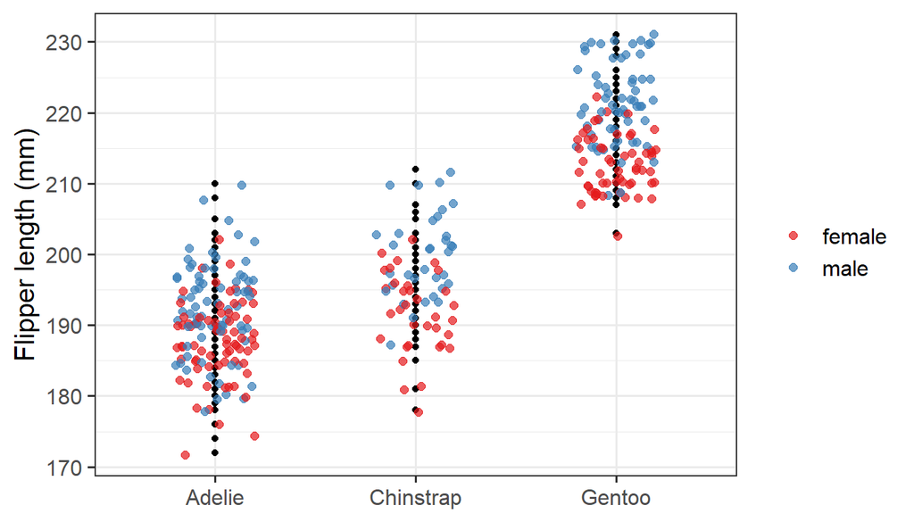

```r
ggplot(data = penguins, aes(x = species, y = flipper_length_mm)) +
  geom_point() +
  geom_jitter(aes(color = sex), width = 0.2, size = 2, alpha = 0.7) +
  labs(x = NULL, y = "Flipper length (mm)") +
  scale_color_brewer(NULL, palette = "Set1", na.translate = FALSE)
```

Note: `geom_jitter` is a shortcut for `geom_point(position = "jitter")`

### Line plot

Line plot of mean flipper length at each study year by species

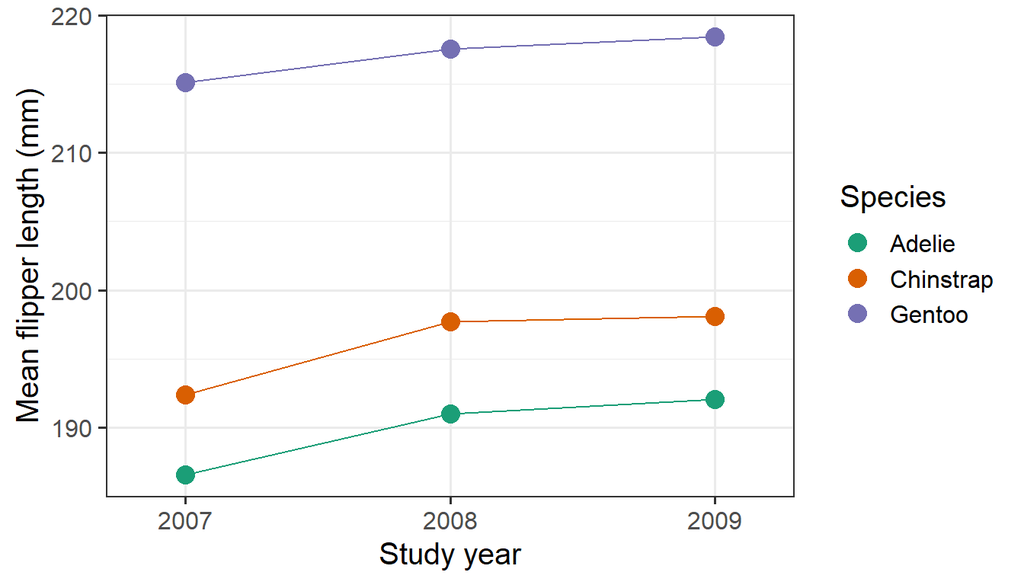

```r
line_species <- penguins %>%
  group_by(species, year) %>%
  summarise(mean = mean(flipper_length_mm, na.rm = TRUE)) %>%
  ggplot(aes(x = as.character(year), y = mean, group = species, color = species)) +
  geom_point(size = 4) +
  geom_line(show.legend = FALSE) +
  scale_x_discrete("Study year", expand = c(0.1, 0.1)) +
  scale_y_continuous("Mean flipper length (mm)") +
  scale_color_brewer("Species", palette = "Dark2")

line_species
```

### 2d density plot

A 2d density plot is useful to study the relationship between two numeric variables if there are huge number of points.

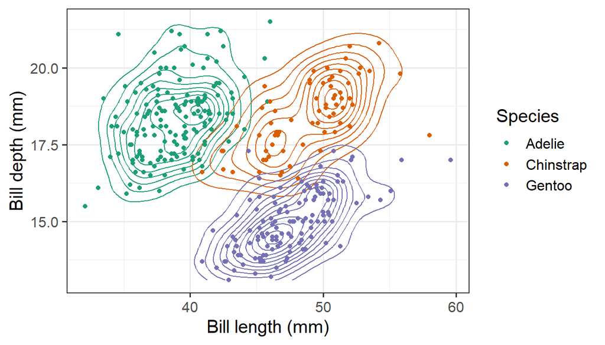

```r
ggplot(data = penguins, aes(x = bill_length_mm, y = bill_depth_mm, color = species)) +
  geom_density_2d(show.legend = FALSE) +
  geom_point() +
  labs(x = "Bill length (mm)", y = "Bill depth (mm)") +
  scale_color_brewer("Species", palette = "Dark2")
```

## Visualizing amounts

We might be interested in visualizing amounts i.e. numerical values for some set of categories

### Bar plot

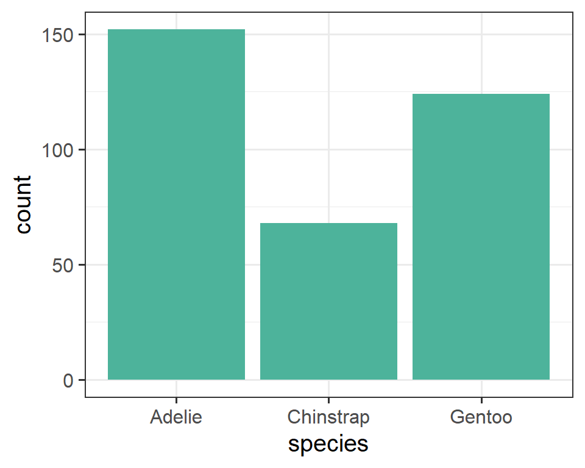

```r
ggplot(data = penguins, aes(x = species)) +
  geom_bar(fill = "#4db39b")
```

You could also calculate counts in advance and plot it but you need to use `stat = "identity"`

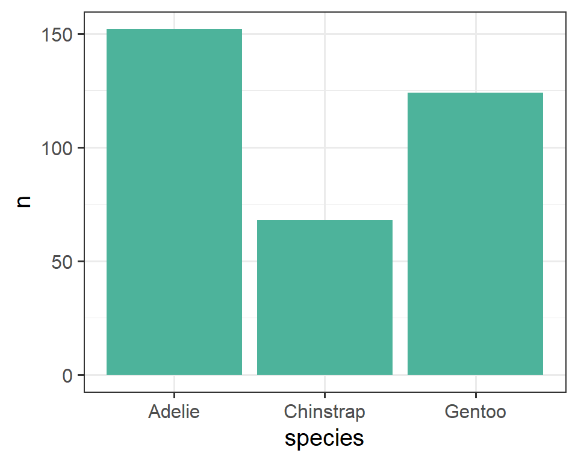

```r
# Count per species
species_count <- penguins %>%
  count(species)

# use stat = "identity"
ggplot(data = species_count, aes(x = species, y = n)) +
  geom_bar(stat = "identity", fill = "#4db39b")
```

Or, just use `geom_col()`

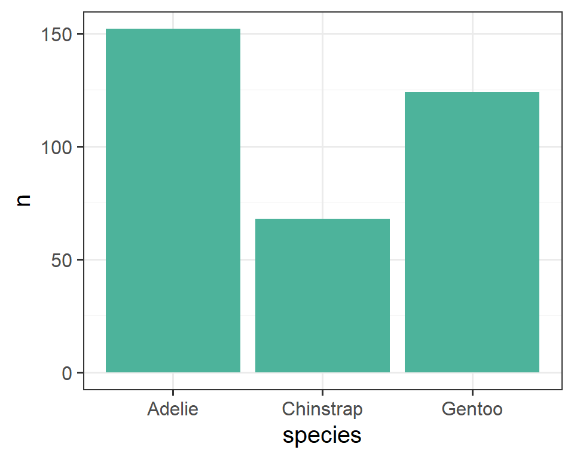

```r
ggplot(data = species_count, aes(x = species, y = n)) +
  geom_col(fill = "#4db39b")
```

Sometimes x-axis labels identifying each bar take up a lot of horizontal space

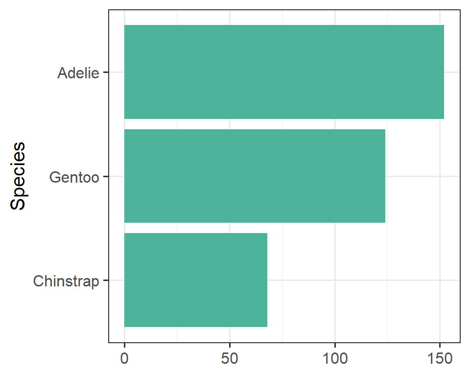

```r
ggplot(species_count, aes(x = fct_reorder(species, n), y = n)) +
  geom_bar(stat = "identity", fill = "#4db39b") +
  labs(x = "Species", y = NULL) +
  coord_flip()
```

Grouped bar plot

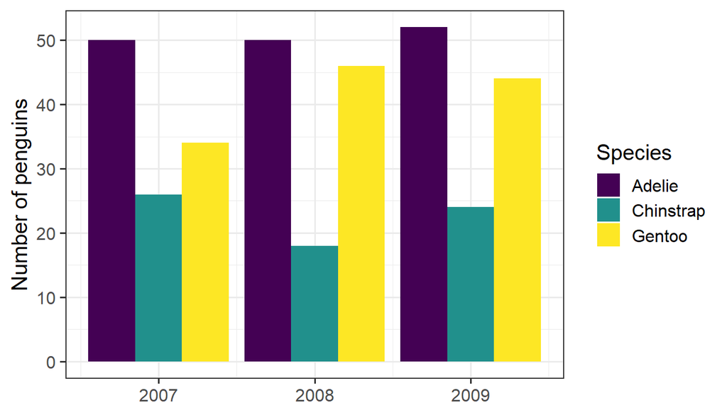

```r
groupedbar_species <- ggplot(data = penguins, aes(x = year, fill = species)) +
  geom_bar(position = "dodge") +
  labs(x = NULL, y = "Number of penguins") +
  scale_fill_viridis_d("Species")

groupedbar_species
```

Stacked bar plot

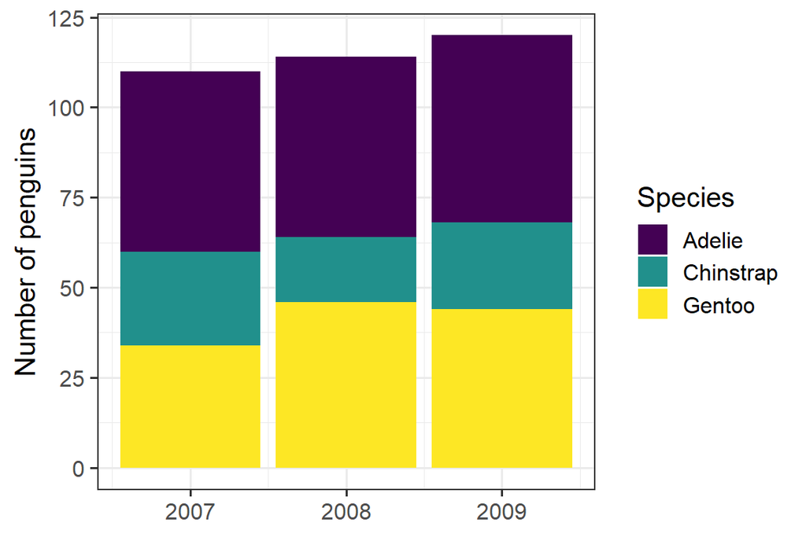

```r
ggplot(data = penguins, aes(x = year, fill = species)) +
  geom_bar(position = "stack") +
  labs(x = NULL, y = "Number of penguins") +
  scale_fill_viridis_d("Species")
```

Percent stacked bar plot

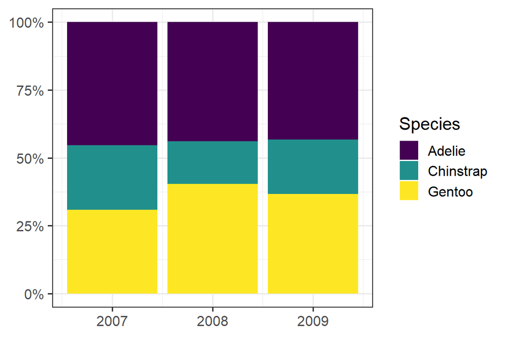

```r
stackedbar_species <- ggplot(data = penguins, aes(x = year, fill = species)) +
  geom_bar(position = "fill") +
  labs(x = NULL, y = NULL) +
  scale_fill_viridis_d("Species") +
  scale_y_continuous(labels = scales::percent_format())

stackedbar_species
```

## Visualizing distributions

To understand how a particular variable is distributed in a dataset

### Boxplot

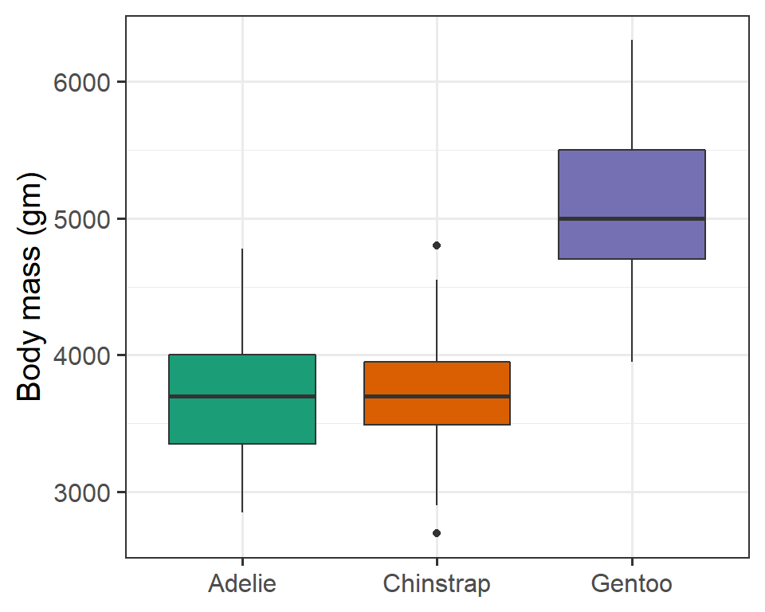

```r
ggplot(data = penguins, aes(x = species, y = body_mass_g, fill = species)) +
  geom_boxplot(show.legend = FALSE) +
  labs(x = NULL, y = "Body mass (gm)") +
  scale_fill_brewer(palette = "Dark2")
```

### Violin plot

Similar to box plots except they also show the kernel probability density of the data at different values

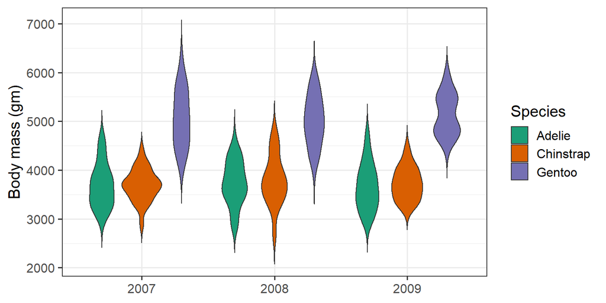

```r
ggplot(data = penguins, aes(x = factor(year), y = body_mass_g, fill = species)) +
  geom_violin(trim = FALSE) +
  labs(x = NULL, y = "Body mass (gm)") +
  scale_fill_brewer("Species", palette = "Dark2")
```

### histogram and density plot

Histogram count plot for single distribution

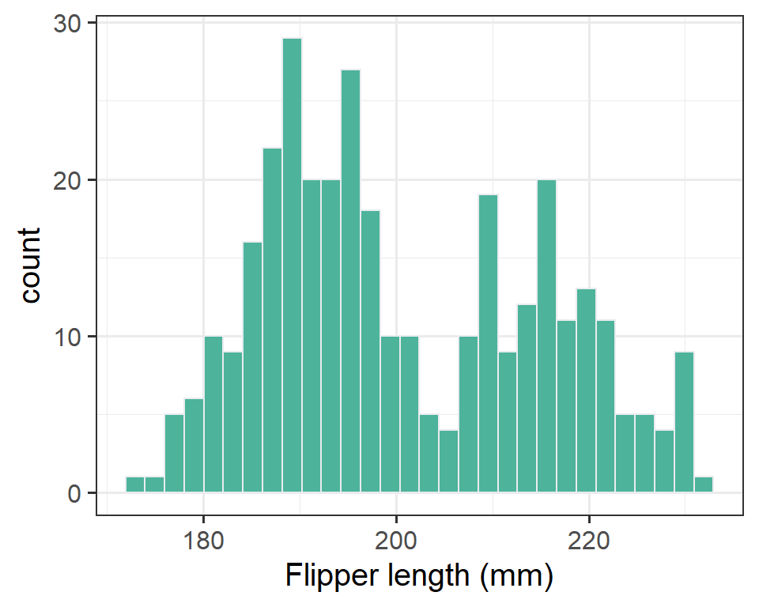

```r
hist_flipper <- ggplot(penguins, aes(x = flipper_length_mm)) +
  geom_histogram(fill = "#4db39b", color = "#e9ecef") +
  labs(x = "Flipper length (mm)")

hist_flipper
```

Visualizing two distributions using pyramid plot

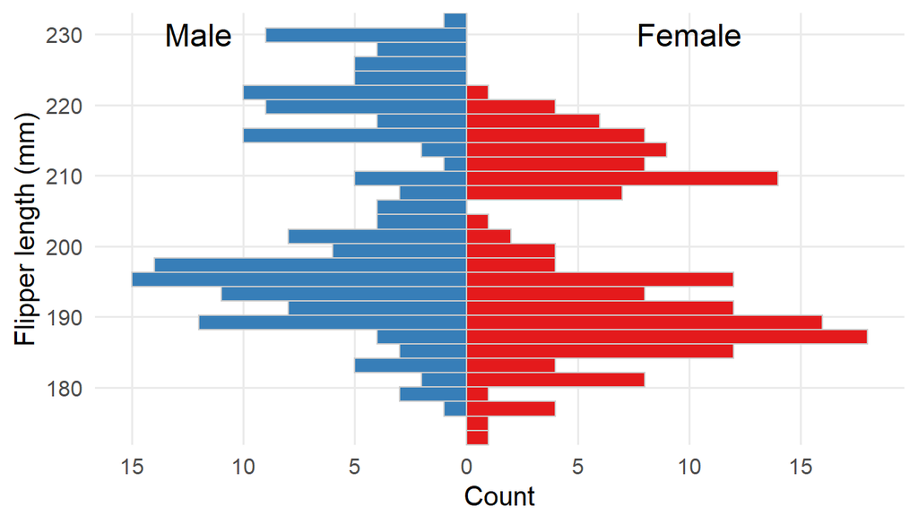

```r
ggplot(penguins, aes(x = flipper_length_mm, fill = sex)) +
  geom_histogram(
    aes(y = after_stat(ifelse(fill == unique(fill)[1], 1, -1) * count)),
    color = "gray80") +
  scale_x_continuous("Flipper length (mm)", expand = c(0, 0)) +
  scale_y_continuous("Count", breaks = seq(-20, 20, 5), labels = abs(seq(-20, 20, 5))) +
  scale_fill_brewer(palette = "Set1", guide = "none") +
  annotate("text", x = 230, y = c(-12, 10), label = c("Male", "Female"), size = 6) +
  coord_flip() +
  theme_minimal(base_size = 15) +
  theme(panel.grid.minor = element_blank())
```

Density plot for visualizing multiple distributions at the same time

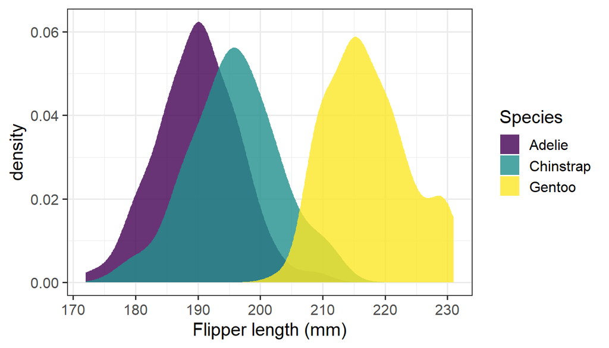

```r
ggplot(penguins, aes(x = flipper_length_mm, fill = species)) +
  geom_density(alpha = 0.8, color = "transparent") +
  labs(x = "Flipper length (mm)") +
  scale_fill_viridis_d("Species")
```

Use `after_stat()` to modify mapping from computed values by `stats`

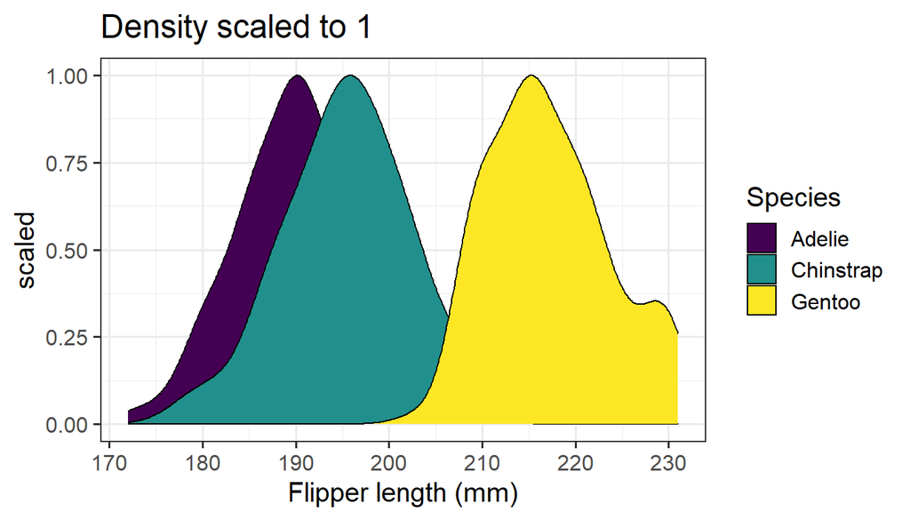

```r
ggplot(penguins, aes(x = flipper_length_mm, fill = species)) +
  geom_density(aes(y = after_stat(scaled))) +
  labs(x = "Flipper length (mm)", title = "Density scaled to 1") +
  scale_fill_viridis_d("Species")
```

### Ridge plot

Visualizing multiple distributions along the horizontal axis by staggering the distribution plots in the vertical direction

You need `{ggridges}` package for this plot

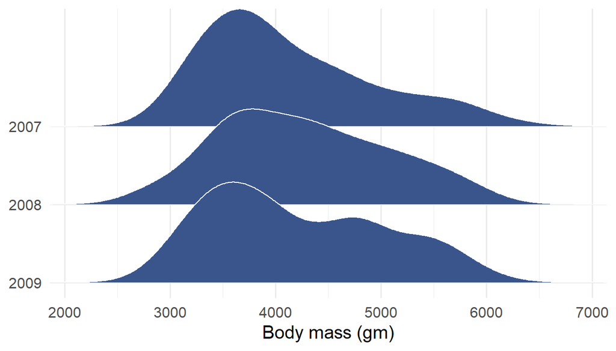

```r
ridge_body_mass <- ggplot(
  penguins, aes(x = body_mass_g, y = fct_rev(factor(year)))) +
  geom_density_ridges(
    scale = 1.5, fill = "#39558CFF", color = "white") +
  scale_x_continuous("Body mass (gm)", expand = c(0, 0)) +
  scale_y_discrete(NULL, expand = c(0, 0.2, 0, 1.5)) +
  theme_minimal(base_size = 15)

ridge_body_mass
```

Comparing two distribution over time

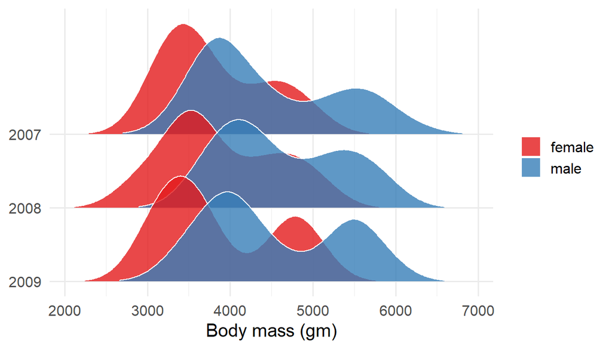

```r
penguins %>%
  drop_na(sex) %>%
  ggplot(aes(x = body_mass_g, y = fct_rev(factor(year)), fill = sex)) +
  geom_density_ridges(
    scale = 1.5, rel_min_height = 0.01, color = "white", alpha = 0.8) +
  scale_x_continuous("Body mass (gm)", expand = c(0, 0)) +
  scale_y_discrete(NULL, expand = c(0, 0.2, 0, 1.7)) +
  scale_fill_brewer(NULL, palette = "Set1") +
  theme_minimal(base_size = 15)
```

## Combining plots

`{patchwork}` R package has made combining multiple plots ridiculuous simple

### Horizontal layout

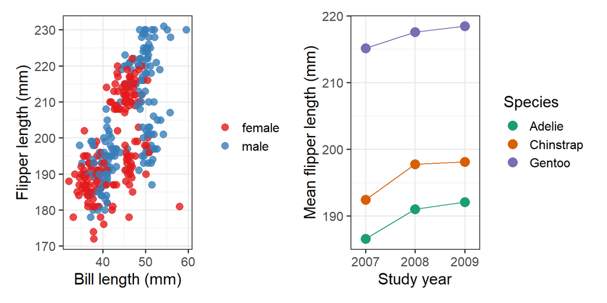

```r
# combine two plots horizontally
scatter_sex + line_species
```

or you can use “|” too

### Vertical layout

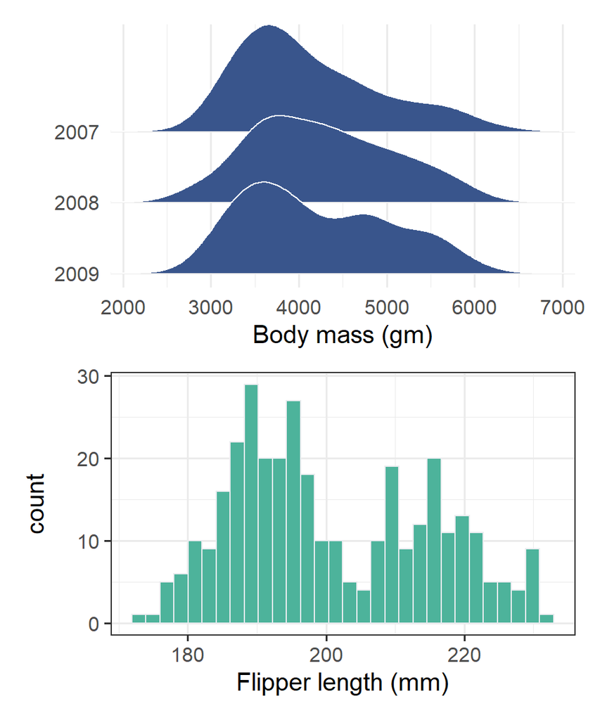

```r
# stack two plots
ridge_body_mass / hist_flipper
```

### Nested layout

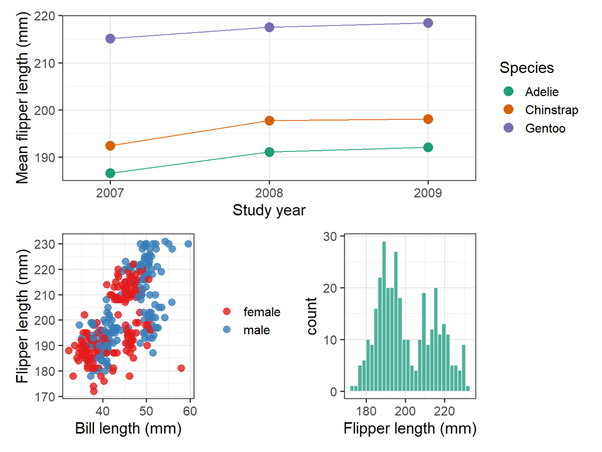

```r
patch <- line_species / (scatter_sex | hist_flipper)

patch
```

Be careful with the operator precedence rule (e.g. / is evaluated before |)

`{patchwork}` provides `wrap_plots()` for a more functional approach to assembly

### Annotating plots

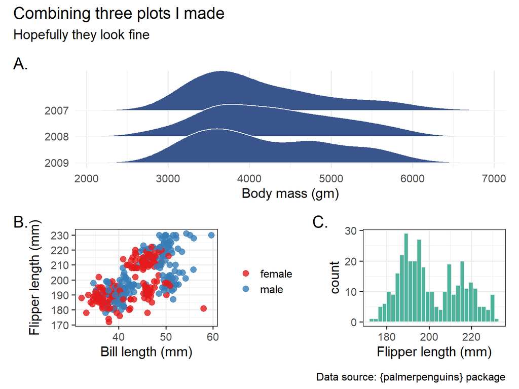

```r
(ridge_body_mass / (scatter_sex | hist_flipper)) +
  plot_annotation(
    title = "Combining three plots I made",
    subtitle = "Hopefully they look fine",
    caption = "Data source: {palmerpenguins} package",
    tag_levels = "A", tag_suffix = ".")
```

### Modifying patches

Use `&` to add elements to all subplots in the patchwork

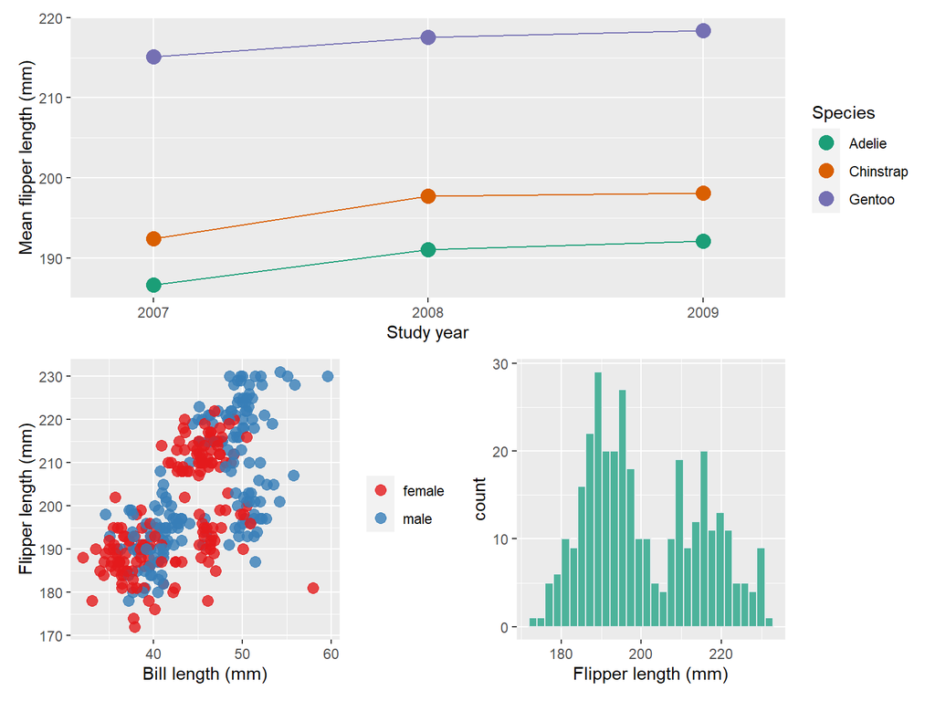

```r
patch & theme_gray()
```

and `*` to add the element to all the subplots in the current nesting level

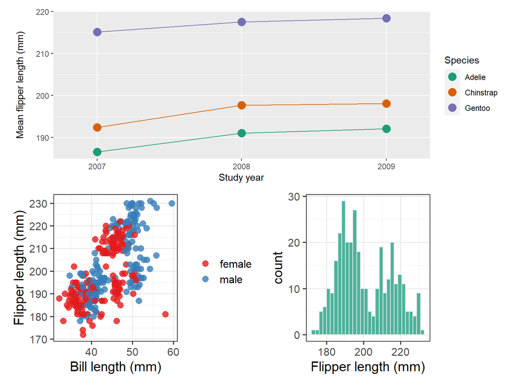

```r
patch * theme_gray()
```

### Controlling guides

If multiple plots have same guide, using `guides = "collect"` in `plot_layout()` drops the duplicate guide

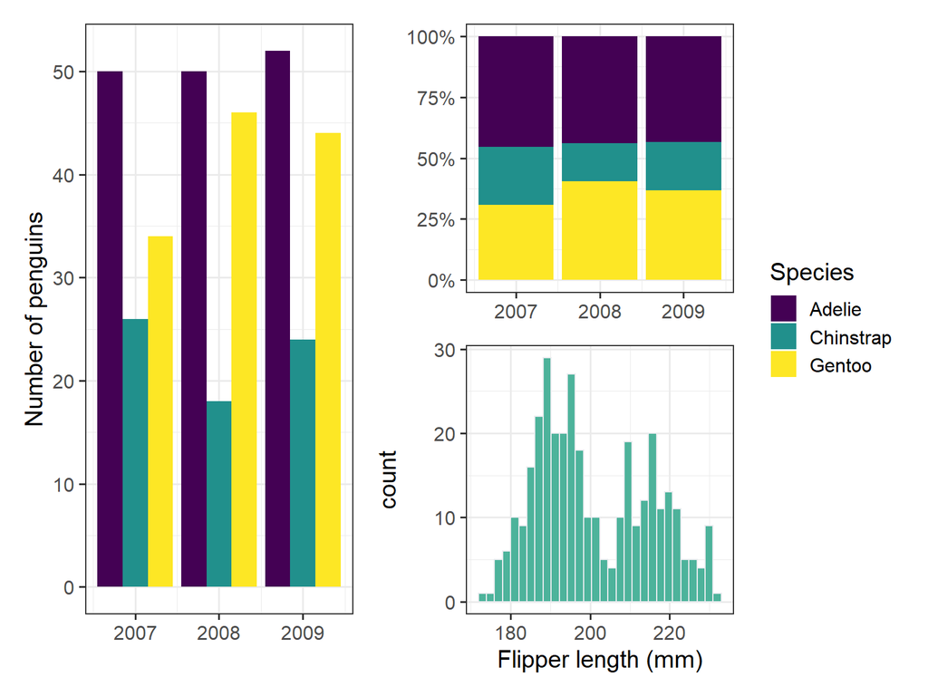

```r
(groupedbar_species | (stackedbar_species / hist_flipper)) +
  plot_layout(guides = "collect")
```